# Risk Factor Analysis

## Outcome Variable

**Outcome Variable:** y_rate_haz

## Predictor Variables

**Intervention Variable:** trth2o

**Adjustment Set:**

unadjusted

## Stratifying Variables

The analysis was stratified on these variable(s):

- agecat
- studyid
- country

## Data Summary

| agecat | studyid | country | trth2o | n_cell | n |
| --- | --- | --- | --- | --- | --- |
| 0-3 months | ki0047075b-MAL-ED | BANGLADESH | 0 | 2 | 134 |
| 0-3 months | ki0047075b-MAL-ED | BANGLADESH | 1 | 132 | 134 |
| 0-3 months | ki1017093b-PROVIDE | BANGLADESH | 0 | 620 | 634 |
| 0-3 months | ki1017093b-PROVIDE | BANGLADESH | 1 | 14 | 634 |
| 0-3 months | ki1017093c-NIH-Crypto | BANGLADESH | 0 | 319 | 720 |
| 0-3 months | ki1017093c-NIH-Crypto | BANGLADESH | 1 | 401 | 720 |
| 0-3 months | ki0047075b-MAL-ED | BRAZIL | 0 | 72 | 84 |
| 0-3 months | ki0047075b-MAL-ED | BRAZIL | 1 | 12 | 84 |
| 0-3 months | ki0047075b-MAL-ED | INDIA | 0 | 4 | 6 |
| 0-3 months | ki0047075b-MAL-ED | INDIA | 1 | 2 | 6 |
| 0-3 months | ki1000108-CMC-V-BCS-2002 | INDIA | 1 | 25 | 25 |
| 0-3 months | ki1000108-IRC | INDIA | 1 | 118 | 118 |
| 0-3 months | ki0047075b-MAL-ED | NEPAL | 0 | 12 | 63 |
| 0-3 months | ki0047075b-MAL-ED | NEPAL | 1 | 51 | 63 |
| 0-3 months | ki0047075b-MAL-ED | PERU | 0 | 9 | 46 |
| 0-3 months | ki0047075b-MAL-ED | PERU | 1 | 37 | 46 |
| 0-3 months | ki0047075b-MAL-ED | SOUTH AFRICA | 0 | 9 | 10 |
| 0-3 months | ki0047075b-MAL-ED | SOUTH AFRICA | 1 | 1 | 10 |
| 0-3 months | ki0047075b-MAL-ED | TANZANIA, UNITED REPUBLIC OF | 0 | 32 | 38 |
| 0-3 months | ki0047075b-MAL-ED | TANZANIA, UNITED REPUBLIC OF | 1 | 6 | 38 |
| 3-6 months | ki0047075b-MAL-ED | BANGLADESH | 0 | 2 | 132 |
| 3-6 months | ki0047075b-MAL-ED | BANGLADESH | 1 | 130 | 132 |
| 3-6 months | ki1017093b-PROVIDE | BANGLADESH | 0 | 561 | 574 |
| 3-6 months | ki1017093b-PROVIDE | BANGLADESH | 1 | 13 | 574 |
| 3-6 months | ki1017093c-NIH-Crypto | BANGLADESH | 0 | 313 | 695 |
| 3-6 months | ki1017093c-NIH-Crypto | BANGLADESH | 1 | 382 | 695 |
| 3-6 months | ki0047075b-MAL-ED | BRAZIL | 0 | 90 | 103 |
| 3-6 months | ki0047075b-MAL-ED | BRAZIL | 1 | 13 | 103 |
| 3-6 months | ki0047075b-MAL-ED | INDIA | 0 | 4 | 7 |
| 3-6 months | ki0047075b-MAL-ED | INDIA | 1 | 3 | 7 |

[output cut: 56 more lines]

The following strata were considered:

- agecat: 0-3 months, studyid: ki0047075b-MAL-ED, country: BANGLADESH
- agecat: 0-3 months, studyid: ki0047075b-MAL-ED, country: BRAZIL
- agecat: 0-3 months, studyid: ki0047075b-MAL-ED, country: INDIA
- agecat: 0-3 months, studyid: ki0047075b-MAL-ED, country: NEPAL
- agecat: 0-3 months, studyid: ki0047075b-MAL-ED, country: PERU
- agecat: 0-3 months, studyid: ki0047075b-MAL-ED, country: SOUTH AFRICA
- agecat: 0-3 months, studyid: ki0047075b-MAL-ED, country: TANZANIA, UNITED REPUBLIC OF
- agecat: 0-3 months, studyid: ki1000108-CMC-V-BCS-2002, country: INDIA
- agecat: 0-3 months, studyid: ki1000108-IRC, country: INDIA
- agecat: 0-3 months, studyid: ki1017093b-PROVIDE, country: BANGLADESH
- agecat: 0-3 months, studyid: ki1017093c-NIH-Crypto, country: BANGLADESH
- agecat: 12-24 months, studyid: ki0047075b-MAL-ED, country: BANGLADESH
- agecat: 12-24 months, studyid: ki0047075b-MAL-ED, country: BRAZIL
- agecat: 12-24 months, studyid: ki0047075b-MAL-ED, country: INDIA
- agecat: 12-24 months, studyid: ki0047075b-MAL-ED, country: NEPAL
- agecat: 12-24 months, studyid: ki0047075b-MAL-ED, country: PERU
- agecat: 12-24 months, studyid: ki0047075b-MAL-ED, country: SOUTH AFRICA
- agecat: 12-24 months, studyid: ki0047075b-MAL-ED, country: TANZANIA, UNITED REPUBLIC OF
- agecat: 12-24 months, studyid: ki1000108-CMC-V-BCS-2002, country: INDIA
- agecat: 12-24 months, studyid: ki1000108-IRC, country: INDIA
- agecat: 12-24 months, studyid: ki1017093b-PROVIDE, country: BANGLADESH
- agecat: 12-24 months, studyid: ki1017093c-NIH-Crypto, country: BANGLADESH
- agecat: 12-24 months, studyid: ki1113344-GMS-Nepal, country: NEPAL
- agecat: 3-6 months, studyid: ki0047075b-MAL-ED, country: BANGLADESH
- agecat: 3-6 months, studyid: ki0047075b-MAL-ED, country: BRAZIL
- agecat: 3-6 months, studyid: ki0047075b-MAL-ED, country: INDIA
- agecat: 3-6 months, studyid: ki0047075b-MAL-ED, country: NEPAL
- agecat: 3-6 months, studyid: ki0047075b-MAL-ED, country: PERU
- agecat: 3-6 months, studyid: ki0047075b-MAL-ED, country: SOUTH AFRICA
- agecat: 3-6 months, studyid: ki0047075b-MAL-ED, country: TANZANIA, UNITED REPUBLIC OF
- agecat: 3-6 months, studyid: ki1000108-CMC-V-BCS-2002, country: INDIA
- agecat: 3-6 months, studyid: ki1000108-IRC, country: INDIA
- agecat: 3-6 months, studyid: ki1017093b-PROVIDE, country: BANGLADESH
- agecat: 3-6 months, studyid: ki1017093c-NIH-Crypto, country: BANGLADESH
- agecat: 3-6 months, studyid: ki1113344-GMS-Nepal, country: NEPAL
- agecat: 6-12 months, studyid: ki0047075b-MAL-ED, country: BANGLADESH
- agecat: 6-12 months, studyid: ki0047075b-MAL-ED, country: BRAZIL
- agecat: 6-12 months, studyid: ki0047075b-MAL-ED, country: INDIA
- agecat: 6-12 months, studyid: ki0047075b-MAL-ED, country: NEPAL
- agecat: 6-12 months, studyid: ki0047075b-MAL-ED, country: PERU
- agecat: 6-12 months, studyid: ki0047075b-MAL-ED, country: SOUTH AFRICA
- agecat: 6-12 months, studyid: ki0047075b-MAL-ED, country: TANZANIA, UNITED REPUBLIC OF
- agecat: 6-12 months, studyid: ki1000108-CMC-V-BCS-2002, country: INDIA
- agecat: 6-12 months, studyid: ki1000108-IRC, country: INDIA
- agecat: 6-12 months, studyid: ki1017093b-PROVIDE, country: BANGLADESH
- agecat: 6-12 months, studyid: ki1017093c-NIH-Crypto, country: BANGLADESH
- agecat: 6-12 months, studyid: ki1113344-GMS-Nepal, country: NEPAL

## Methods Detail

We’re interested in the causal parameters $E[Y_a]$ for all values of $a \in \mathcal{A}$. These parameters represent the mean outcome if, possibly contrary to fact, we intervened to set all units to have $A=a$. Under the randomization and positivity assumptions, these are identified by the statistical parameters $\psi_a=E_W[E_{Y|A,W}(Y|A=a,W)]$. In addition, we’re interested in the mean of $Y$, $E[Y]$ under no intervention (the observed mean). We will estimate these parameters by using SuperLearner to fit the relevant likelihood factors – $E_{Y|A,W}(Y|A=a,W)$ and $p(A=a|W)$, and then updating our likelihood fit using a joint TMLE.

For unadjusted analyses ($W=\{\}$), initial likelihoods were estimated using Lrnr_glm to estimate the simple $E(Y|A)$ and Lrnr_mean to estimate $p(A)$. For adjusted analyses, a small library containing Lrnr_glmnet, Lrnr_xgboost, and Lrnr_mean was used.

Having estimated these parameters, we will then use the delta method to estimate relative risks and attributable risks relative to a prespecified baseline level of $A$.

[output not shown]

[output cut: 977 more lines]

[output not shown]

# Results Detail

## Results Plots

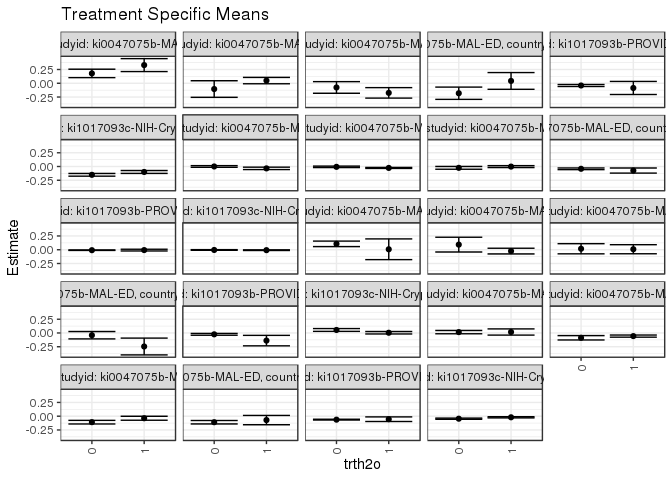

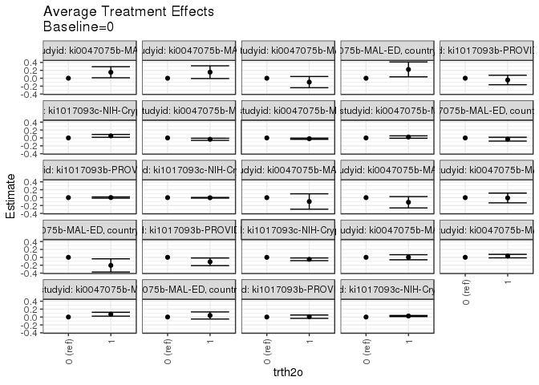

## Results Table

### Parameter: TSM

| agecat | studyid | country | intervention_level | baseline_level | estimate | ci_lower | ci_upper |
| --- | --- | --- | --- | --- | --- | --- | --- |
| 0-3 months | ki0047075b-MAL-ED | BRAZIL | 0 | NA | 0.1792561 | 0.1027959 | 0.2557163 |
| 0-3 months | ki0047075b-MAL-ED | BRAZIL | 1 | NA | 0.3304245 | 0.2129626 | 0.4478863 |
| 0-3 months | ki0047075b-MAL-ED | NEPAL | 0 | NA | -0.1046518 | -0.2555314 | 0.0462279 |
| 0-3 months | ki0047075b-MAL-ED | NEPAL | 1 | NA | 0.0489262 | -0.0089978 | 0.1068502 |
| 0-3 months | ki0047075b-MAL-ED | PERU | 0 | NA | -0.0758361 | -0.1816493 | 0.0299771 |
| 0-3 months | ki0047075b-MAL-ED | PERU | 1 | NA | -0.1741065 | -0.2690571 | -0.0791560 |
| 0-3 months | ki0047075b-MAL-ED | TANZANIA, UNITED REPUBLIC OF | 0 | NA | -0.1809516 | -0.2923482 | -0.0695550 |
| 0-3 months | ki0047075b-MAL-ED | TANZANIA, UNITED REPUBLIC OF | 1 | NA | 0.0426731 | -0.1094170 | 0.1947631 |
| 0-3 months | ki1017093b-PROVIDE | BANGLADESH | 0 | NA | -0.0403222 | -0.0586822 | -0.0219623 |
| 0-3 months | ki1017093b-PROVIDE | BANGLADESH | 1 | NA | -0.0852495 | -0.2038802 | 0.0333813 |
| 0-3 months | ki1017093c-NIH-Crypto | BANGLADESH | 0 | NA | -0.1509973 | -0.1754248 | -0.1265698 |
| 0-3 months | ki1017093c-NIH-Crypto | BANGLADESH | 1 | NA | -0.0990797 | -0.1251200 | -0.0730395 |
| 3-6 months | ki0047075b-MAL-ED | BRAZIL | 0 | NA | 0.1070668 | 0.0571647 | 0.1569690 |
| 3-6 months | ki0047075b-MAL-ED | BRAZIL | 1 | NA | 0.0084511 | -0.1798343 | 0.1967364 |
| 3-6 months | ki0047075b-MAL-ED | NEPAL | 0 | NA | 0.0930012 | -0.0409602 | 0.2269625 |
| 3-6 months | ki0047075b-MAL-ED | NEPAL | 1 | NA | -0.0243725 | -0.0762821 | 0.0275371 |
| 3-6 months | ki0047075b-MAL-ED | PERU | 0 | NA | 0.0181999 | -0.0741782 | 0.1105781 |
| 3-6 months | ki0047075b-MAL-ED | PERU | 1 | NA | 0.0094077 | -0.0727307 | 0.0915462 |
| 3-6 months | ki0047075b-MAL-ED | TANZANIA, UNITED REPUBLIC OF | 0 | NA | -0.0410643 | -0.1081175 | 0.0259890 |
| 3-6 months | ki0047075b-MAL-ED | TANZANIA, UNITED REPUBLIC OF | 1 | NA | -0.2457527 | -0.3985192 | -0.0929862 |
| 3-6 months | ki1017093b-PROVIDE | BANGLADESH | 0 | NA | -0.0246686 | -0.0412977 | -0.0080394 |
| 3-6 months | ki1017093b-PROVIDE | BANGLADESH | 1 | NA | -0.1383308 | -0.2332995 | -0.0433622 |
| 3-6 months | ki1017093c-NIH-Crypto | BANGLADESH | 0 | NA | 0.0545940 | 0.0289837 | 0.0802043 |
| 3-6 months | ki1017093c-NIH-Crypto | BANGLADESH | 1 | NA | 0.0039791 | -0.0180169 | 0.0259752 |
| 6-12 months | ki0047075b-MAL-ED | BRAZIL | 0 | NA | 0.0155855 | -0.0145235 | 0.0456944 |
| 6-12 months | ki0047075b-MAL-ED | BRAZIL | 1 | NA | 0.0174152 | -0.0389784 | 0.0738089 |
| 6-12 months | ki0047075b-MAL-ED | NEPAL | 0 | NA | -0.0874946 | -0.1272287 | -0.0477605 |
| 6-12 months | ki0047075b-MAL-ED | NEPAL | 1 | NA | -0.0568592 | -0.0765986 | -0.0371199 |
| 6-12 months | ki0047075b-MAL-ED | PERU | 0 | NA | -0.1083468 | -0.1412159 | -0.0754776 |
| 6-12 months | ki0047075b-MAL-ED | PERU | 1 | NA | -0.0372084 | -0.0734686 | -0.0009482 |
| 6-12 months | ki0047075b-MAL-ED | TANZANIA, UNITED REPUBLIC OF | 0 | NA | -0.1091758 | -0.1404418 | -0.0779099 |
| 6-12 months | ki0047075b-MAL-ED | TANZANIA, UNITED REPUBLIC OF | 1 | NA | -0.0701895 | -0.1547940 | 0.0144151 |
| 6-12 months | ki1017093b-PROVIDE | BANGLADESH | 0 | NA | -0.0628179 | -0.0698549 | -0.0557809 |
| 6-12 months | ki1017093b-PROVIDE | BANGLADESH | 1 | NA | -0.0543168 | -0.0961932 | -0.0124404 |
| 6-12 months | ki1017093c-NIH-Crypto | BANGLADESH | 0 | NA | -0.0453478 | -0.0555171 | -0.0351786 |
| 6-12 months | ki1017093c-NIH-Crypto | BANGLADESH | 1 | NA | -0.0198227 | -0.0300322 | -0.0096133 |
| 12-24 months | ki0047075b-MAL-ED | BRAZIL | 0 | NA | 0.0007187 | -0.0140905 | 0.0155279 |
| 12-24 months | ki0047075b-MAL-ED | BRAZIL | 1 | NA | -0.0340767 | -0.0558067 | -0.0123468 |
| 12-24 months | ki0047075b-MAL-ED | NEPAL | 0 | NA | -0.0061167 | -0.0191082 | 0.0068747 |
| 12-24 months | ki0047075b-MAL-ED | NEPAL | 1 | NA | -0.0256788 | -0.0341420 | -0.0172156 |
| 12-24 months | ki0047075b-MAL-ED | PERU | 0 | NA | -0.0242099 | -0.0492909 | 0.0008710 |
| 12-24 months | ki0047075b-MAL-ED | PERU | 1 | NA | -0.0017132 | -0.0186903 | 0.0152639 |
| 12-24 months | ki0047075b-MAL-ED | TANZANIA, UNITED REPUBLIC OF | 0 | NA | -0.0415527 | -0.0566565 | -0.0264488 |
| 12-24 months | ki0047075b-MAL-ED | TANZANIA, UNITED REPUBLIC OF | 1 | NA | -0.0732993 | -0.1193519 | -0.0272467 |
| 12-24 months | ki1017093b-PROVIDE | BANGLADESH | 0 | NA | -0.0082189 | -0.0121359 | -0.0043020 |
| 12-24 months | ki1017093b-PROVIDE | BANGLADESH | 1 | NA | -0.0062543 | -0.0218834 | 0.0093749 |
| 12-24 months | ki1017093c-NIH-Crypto | BANGLADESH | 0 | NA | -0.0041994 | -0.0096421 | 0.0012433 |
| 12-24 months | ki1017093c-NIH-Crypto | BANGLADESH | 1 | NA | -0.0075280 | -0.0133970 | -0.0016591 |

### Parameter: E(Y)

| agecat | studyid | country | intervention_level | baseline_level | estimate | ci_lower | ci_upper |
| --- | --- | --- | --- | --- | --- | --- | --- |
| 0-3 months | ki0047075b-MAL-ED | BRAZIL | NA | NA | 0.2008516 | 0.1322496 | 0.2694535 |
| 0-3 months | ki0047075b-MAL-ED | NEPAL | NA | NA | 0.0196732 | -0.0373357 | 0.0766822 |
| 0-3 months | ki0047075b-MAL-ED | PERU | NA | NA | -0.1548797 | -0.2348247 | -0.0749347 |
| 0-3 months | ki0047075b-MAL-ED | TANZANIA, UNITED REPUBLIC OF | NA | NA | -0.1456424 | -0.2459764 | -0.0453085 |
| 0-3 months | ki1017093b-PROVIDE | BANGLADESH | NA | NA | -0.0413143 | -0.0594662 | -0.0231624 |
| 0-3 months | ki1017093c-NIH-Crypto | BANGLADESH | NA | NA | -0.1220821 | -0.1402761 | -0.1038881 |
| 3-6 months | ki0047075b-MAL-ED | BRAZIL | NA | NA | 0.0946202 | 0.0445560 | 0.1446843 |
| 3-6 months | ki0047075b-MAL-ED | NEPAL | NA | NA | -0.0043331 | -0.0540186 | 0.0453524 |
| 3-6 months | ki0047075b-MAL-ED | PERU | NA | NA | 0.0112021 | -0.0568449 | 0.0792490 |
| 3-6 months | ki0047075b-MAL-ED | TANZANIA, UNITED REPUBLIC OF | NA | NA | -0.0703055 | -0.1355760 | -0.0050350 |
| 3-6 months | ki1017093b-PROVIDE | BANGLADESH | NA | NA | -0.0272428 | -0.0436954 | -0.0107902 |
| 3-6 months | ki1017093c-NIH-Crypto | BANGLADESH | NA | NA | 0.0267740 | 0.0099602 | 0.0435879 |
| 6-12 months | ki0047075b-MAL-ED | BRAZIL | NA | NA | 0.0158164 | -0.0114385 | 0.0430713 |
| 6-12 months | ki0047075b-MAL-ED | NEPAL | NA | NA | -0.0620266 | -0.0799254 | -0.0441279 |
| 6-12 months | ki0047075b-MAL-ED | PERU | NA | NA | -0.0517264 | -0.0824460 | -0.0210068 |
| 6-12 months | ki0047075b-MAL-ED | TANZANIA, UNITED REPUBLIC OF | NA | NA | -0.1034705 | -0.1332011 | -0.0737399 |
| 6-12 months | ki1017093b-PROVIDE | BANGLADESH | NA | NA | -0.0626151 | -0.0695574 | -0.0556729 |
| 6-12 months | ki1017093c-NIH-Crypto | BANGLADESH | NA | NA | -0.0315658 | -0.0388594 | -0.0242722 |
| 12-24 months | ki0047075b-MAL-ED | BRAZIL | NA | NA | -0.0036730 | -0.0170893 | 0.0097433 |
| 12-24 months | ki0047075b-MAL-ED | NEPAL | NA | NA | -0.0223791 | -0.0299168 | -0.0148415 |
| 12-24 months | ki0047075b-MAL-ED | PERU | NA | NA | -0.0064000 | -0.0210549 | 0.0082548 |
| 12-24 months | ki0047075b-MAL-ED | TANZANIA, UNITED REPUBLIC OF | NA | NA | -0.0460879 | -0.0610026 | -0.0311732 |
| 12-24 months | ki1017093b-PROVIDE | BANGLADESH | NA | NA | -0.0081718 | -0.0120131 | -0.0043304 |
| 12-24 months | ki1017093c-NIH-Crypto | BANGLADESH | NA | NA | -0.0057326 | -0.0097260 | -0.0017391 |

### Parameter: ATE

| agecat | studyid | country | intervention_level | baseline_level | estimate | ci_lower | ci_upper |
| --- | --- | --- | --- | --- | --- | --- | --- |
| 0-3 months | ki0047075b-MAL-ED | BRAZIL | 0 | 0 | 0.0000000 | 0.0000000 | 0.0000000 |
| 0-3 months | ki0047075b-MAL-ED | BRAZIL | 1 | 0 | 0.1511684 | 0.0110132 | 0.2913235 |
| 0-3 months | ki0047075b-MAL-ED | NEPAL | 0 | 0 | 0.0000000 | 0.0000000 | 0.0000000 |
| 0-3 months | ki0047075b-MAL-ED | NEPAL | 1 | 0 | 0.1535779 | -0.0080385 | 0.3151943 |
| 0-3 months | ki0047075b-MAL-ED | PERU | 0 | 0 | 0.0000000 | 0.0000000 | 0.0000000 |
| 0-3 months | ki0047075b-MAL-ED | PERU | 1 | 0 | -0.0982704 | -0.2404395 | 0.0438986 |
| 0-3 months | ki0047075b-MAL-ED | TANZANIA, UNITED REPUBLIC OF | 0 | 0 | 0.0000000 | 0.0000000 | 0.0000000 |
| 0-3 months | ki0047075b-MAL-ED | TANZANIA, UNITED REPUBLIC OF | 1 | 0 | 0.2236247 | 0.0351026 | 0.4121468 |
| 0-3 months | ki1017093b-PROVIDE | BANGLADESH | 0 | 0 | 0.0000000 | 0.0000000 | 0.0000000 |
| 0-3 months | ki1017093b-PROVIDE | BANGLADESH | 1 | 0 | -0.0449272 | -0.1649704 | 0.0751159 |
| 0-3 months | ki1017093c-NIH-Crypto | BANGLADESH | 0 | 0 | 0.0000000 | 0.0000000 | 0.0000000 |
| 0-3 months | ki1017093c-NIH-Crypto | BANGLADESH | 1 | 0 | 0.0519175 | 0.0162133 | 0.0876218 |
| 3-6 months | ki0047075b-MAL-ED | BRAZIL | 0 | 0 | 0.0000000 | 0.0000000 | 0.0000000 |
| 3-6 months | ki0047075b-MAL-ED | BRAZIL | 1 | 0 | -0.0986158 | -0.2934018 | 0.0961703 |
| 3-6 months | ki0047075b-MAL-ED | NEPAL | 0 | 0 | 0.0000000 | 0.0000000 | 0.0000000 |
| 3-6 months | ki0047075b-MAL-ED | NEPAL | 1 | 0 | -0.1173736 | -0.2610408 | 0.0262936 |
| 3-6 months | ki0047075b-MAL-ED | PERU | 0 | 0 | 0.0000000 | 0.0000000 | 0.0000000 |
| 3-6 months | ki0047075b-MAL-ED | PERU | 1 | 0 | -0.0087922 | -0.1324063 | 0.1148219 |
| 3-6 months | ki0047075b-MAL-ED | TANZANIA, UNITED REPUBLIC OF | 0 | 0 | 0.0000000 | 0.0000000 | 0.0000000 |
| 3-6 months | ki0047075b-MAL-ED | TANZANIA, UNITED REPUBLIC OF | 1 | 0 | -0.2046884 | -0.3715229 | -0.0378539 |
| 3-6 months | ki1017093b-PROVIDE | BANGLADESH | 0 | 0 | 0.0000000 | 0.0000000 | 0.0000000 |
| 3-6 months | ki1017093b-PROVIDE | BANGLADESH | 1 | 0 | -0.1136623 | -0.2100758 | -0.0172487 |
| 3-6 months | ki1017093c-NIH-Crypto | BANGLADESH | 0 | 0 | 0.0000000 | 0.0000000 | 0.0000000 |
| 3-6 months | ki1017093c-NIH-Crypto | BANGLADESH | 1 | 0 | -0.0506149 | -0.0843745 | -0.0168552 |
| 6-12 months | ki0047075b-MAL-ED | BRAZIL | 0 | 0 | 0.0000000 | 0.0000000 | 0.0000000 |
| 6-12 months | ki0047075b-MAL-ED | BRAZIL | 1 | 0 | 0.0018298 | -0.0620983 | 0.0657578 |
| 6-12 months | ki0047075b-MAL-ED | NEPAL | 0 | 0 | 0.0000000 | 0.0000000 | 0.0000000 |
| 6-12 months | ki0047075b-MAL-ED | NEPAL | 1 | 0 | 0.0306354 | -0.0137317 | 0.0750025 |
| 6-12 months | ki0047075b-MAL-ED | PERU | 0 | 0 | 0.0000000 | 0.0000000 | 0.0000000 |
| 6-12 months | ki0047075b-MAL-ED | PERU | 1 | 0 | 0.0711384 | 0.0221978 | 0.1200790 |
| 6-12 months | ki0047075b-MAL-ED | TANZANIA, UNITED REPUBLIC OF | 0 | 0 | 0.0000000 | 0.0000000 | 0.0000000 |
| 6-12 months | ki0047075b-MAL-ED | TANZANIA, UNITED REPUBLIC OF | 1 | 0 | 0.0389864 | -0.0512106 | 0.1291833 |
| 6-12 months | ki1017093b-PROVIDE | BANGLADESH | 0 | 0 | 0.0000000 | 0.0000000 | 0.0000000 |
| 6-12 months | ki1017093b-PROVIDE | BANGLADESH | 1 | 0 | 0.0085011 | -0.0339624 | 0.0509647 |
| 6-12 months | ki1017093c-NIH-Crypto | BANGLADESH | 0 | 0 | 0.0000000 | 0.0000000 | 0.0000000 |
| 6-12 months | ki1017093c-NIH-Crypto | BANGLADESH | 1 | 0 | 0.0255251 | 0.0111151 | 0.0399350 |
| 12-24 months | ki0047075b-MAL-ED | BRAZIL | 0 | 0 | 0.0000000 | 0.0000000 | 0.0000000 |
| 12-24 months | ki0047075b-MAL-ED | BRAZIL | 1 | 0 | -0.0347954 | -0.0610919 | -0.0084989 |
| 12-24 months | ki0047075b-MAL-ED | NEPAL | 0 | 0 | 0.0000000 | 0.0000000 | 0.0000000 |
| 12-24 months | ki0047075b-MAL-ED | NEPAL | 1 | 0 | -0.0195620 | -0.0350670 | -0.0040571 |
| 12-24 months | ki0047075b-MAL-ED | PERU | 0 | 0 | 0.0000000 | 0.0000000 | 0.0000000 |
| 12-24 months | ki0047075b-MAL-ED | PERU | 1 | 0 | 0.0224967 | -0.0077898 | 0.0527833 |
| 12-24 months | ki0047075b-MAL-ED | TANZANIA, UNITED REPUBLIC OF | 0 | 0 | 0.0000000 | 0.0000000 | 0.0000000 |
| 12-24 months | ki0047075b-MAL-ED | TANZANIA, UNITED REPUBLIC OF | 1 | 0 | -0.0317467 | -0.0802128 | 0.0167195 |
| 12-24 months | ki1017093b-PROVIDE | BANGLADESH | 0 | 0 | 0.0000000 | 0.0000000 | 0.0000000 |
| 12-24 months | ki1017093b-PROVIDE | BANGLADESH | 1 | 0 | 0.0019647 | -0.0141478 | 0.0180772 |
| 12-24 months | ki1017093c-NIH-Crypto | BANGLADESH | 0 | 0 | 0.0000000 | 0.0000000 | 0.0000000 |
| 12-24 months | ki1017093c-NIH-Crypto | BANGLADESH | 1 | 0 | -0.0033287 | -0.0113329 | 0.0046755 |